# BIOL606_hw_Lecture_11_Hastings

2025-03-12

# Homework Lecture 11

### Lecture Notes

A parsimonious model is the simplest model that adequately explains the data, finding a balance between fit and complexity and only including necessary variables.

If models are within 2 AIC units of each other, they are very similar. Within 5 units is quite similar. Over 10 units is different.

### Question 1: Draw on your extensive personal knowledge of bird nesting biology to come up with 3 hypotheses about how the explanatory variables might affect nestling bodymass. The hypotheses can have one or more IVs (try to come up with a mix).

Hypothesis A: As feedings per day increase, the body mass of the nestlings increases.

Hypothesis B: As the height of the nest increases, the body mass of the nestlings increases.

Hypothesis C: The body mass of the nestlings is significantly related to the type of tree their nest is located in.

```r
offspring <- read_csv('offspring_mass.csv') # Read in data from local directory.
# Convert categorical variables to factors.
offspring$plant <- as.factor(offspring$plant)

# Quality check.
# Check column names.
colnames(offspring)
```

```
## [1] "offspring_mass"   "dist_edge"        "feedings_per_day" "canopy_cover"
## [5] "height"           "plant"
```

```r
# Check data set structure.
str(offspring)
```

```
## spc_tbl_ [100 × 6] (S3: spec_tbl_df/tbl_df/tbl/data.frame)
##  $ offspring_mass  : num [1:100] 30.5 28.1 25.5 31.5 29.2 ...
##  $ dist_edge       : num [1:100] 51.3 70.1 49.1 17.4 50.8 71.6 5.3 13.8 71.9 55.6 ...
##  $ feedings_per_day: num [1:100] 5.6 5 3.1 5.6 5.1 5.1 8 5.6 4 8.6 ...
##  $ canopy_cover    : num [1:100] 0.088 0.532 0.308 0.658 0.807 0.255 0.167 0.627 0.539 0.989 ...
##  $ height          : num [1:100] 8.86 0.2 4.01 4.91 3.41 0.25 7.13 2.45 2.11 4.02 ...
##  $ plant           : Factor w/ 3 levels "maple","oak",..: 2 2 1 3 2 2 1 3 2 2 ...
##  - attr(*, "spec")=
##   .. cols(
##   ..   offspring_mass = col_double(),
##   ..   dist_edge = col_double(),
##   ..   feedings_per_day = col_double(),
##   ..   canopy_cover = col_double(),
##   ..   height = col_double(),
##   ..   plant = col_character()
##   .. )
##  - attr(*, "problems")=<externalptr>
```

```r
# Check for missing values.
colSums(is.na(offspring))
```

```
##   offspring_mass        dist_edge feedings_per_day     canopy_cover
##                0                0                0                0
##           height            plant
##                0                0
```

### Question 2: Build a glm() model for each hypothesis and save it as an object, e.g., modA, modB, modC, etc. Also build a model with only an intercept (~ 1) as the IV.

```r
# Build a glm() model for each hypothesis.

# Model for hypothesis A.
modA <- glm(offspring_mass ~ feedings_per_day, data = offspring)

# Check model diagnostics.
summary(modA)
```

```
##
## Call:
## glm(formula = offspring_mass ~ feedings_per_day, data = offspring)
##
## Coefficients:
##                  Estimate Std. Error t value Pr(>|t|)
## (Intercept)       25.6722     1.1323  22.673  < 2e-16 ***
## feedings_per_day   0.7922     0.1803   4.395 2.81e-05 ***
## ---
## Signif. codes:  0 '***' 0.001 '**' 0.01 '*' 0.05 '.' 0.1 ' ' 1
##
## (Dispersion parameter for gaussian family taken to be 8.929043)
##
##     Null deviance: 1047.50  on 99  degrees of freedom
## Residual deviance:  875.05  on 98  degrees of freedom
## AIC: 506.7
##
## Number of Fisher Scoring iterations: 2
```

```r
Anova(modA)
```

```
## Analysis of Deviance Table (Type II tests)
##
## Response: offspring_mass
##                  LR Chisq Df Pr(>Chisq)
## feedings_per_day   19.314  1  1.109e-05 ***
## ---
## Signif. codes:  0 '***' 0.001 '**' 0.01 '*' 0.05 '.' 0.1 ' ' 1
```

```r
# Model for hypothesis B.
modB <- glm(offspring_mass ~ height, data = offspring)

# Check model diagnostics.
summary(modB)
```

```
##
## Call:
## glm(formula = offspring_mass ~ height, data = offspring)
##
## Coefficients:
##             Estimate Std. Error t value Pr(>|t|)
## (Intercept)  29.8848     0.6742  44.324   <2e-16 ***
## height        0.1449     0.1457   0.994    0.323
## ---
## Signif. codes:  0 '***' 0.001 '**' 0.01 '*' 0.05 '.' 0.1 ' ' 1
##
## (Dispersion parameter for gaussian family taken to be 10.58211)
##
##     Null deviance: 1047.5  on 99  degrees of freedom
## Residual deviance: 1037.0  on 98  degrees of freedom
## AIC: 523.68
##
## Number of Fisher Scoring iterations: 2
```

```r
Anova(modB)
```

```
## Analysis of Deviance Table (Type II tests)
##
## Response: offspring_mass
##        LR Chisq Df Pr(>Chisq)
## height  0.98826  1     0.3202
```

```r
# Model for hypothesis C.
modC <- glm(offspring_mass ~ plant, data = offspring)

# Check model diagnostics.
summary(modC)
```

```
##
## Call:
## glm(formula = offspring_mass ~ plant, data = offspring)
##
## Coefficients:
##                Estimate Std. Error t value Pr(>|t|)
## (Intercept)     30.0336     0.5694  52.750   <2e-16 ***
## plantoak         0.5811     0.7993   0.727    0.469
## plantraspberry   0.7294     0.8052   0.906    0.367
## ---
## Signif. codes:  0 '***' 0.001 '**' 0.01 '*' 0.05 '.' 0.1 ' ' 1
##
## (Dispersion parameter for gaussian family taken to be 10.69769)
##
##     Null deviance: 1047.5  on 99  degrees of freedom
## Residual deviance: 1037.7  on 97  degrees of freedom
## AIC: 525.74
##
## Number of Fisher Scoring iterations: 2
```

```r
Anova(modC)
```

```
## Analysis of Deviance Table (Type II tests)
##
## Response: offspring_mass
##       LR Chisq Df Pr(>Chisq)
## plant  0.91878  2     0.6317
```

```r
# Model for null hypothesis.
mod_null <- glm(offspring_mass ~ 1, data = offspring)

# Check model diagnostics.
summary(mod_null)
```

```
##
## Call:
## glm(formula = offspring_mass ~ 1, data = offspring)
##
## Coefficients:
##             Estimate Std. Error t value Pr(>|t|)
## (Intercept)  30.4719     0.3253   93.68   <2e-16 ***
## ---
## Signif. codes:  0 '***' 0.001 '**' 0.01 '*' 0.05 '.' 0.1 ' ' 1
##
## (Dispersion parameter for gaussian family taken to be 10.58086)
##
##     Null deviance: 1047.5  on 99  degrees of freedom
## Residual deviance: 1047.5  on 99  degrees of freedom
## AIC: 522.69
##
## Number of Fisher Scoring iterations: 2
```

```r
# Used base anova() since Anova() was having issues handling the simpler model.
anova(mod_null)
```

```
## Analysis of Deviance Table
##
## Model: gaussian, link: identity
##
## Response: offspring_mass
##
## Terms added sequentially (first to last)
##
##
##      Df Deviance Resid. Df Resid. Dev F Pr(>F)
## NULL                    99     1047.5
```

### Question 3: Compare these models.

```r
# Create list of candidates models.
Cand.mods <- list(modA, modB, modC, mod_null)

# Perform model selection using AIC.
aictab <- model.sel(Cand.mods)

# Display AIC comparison.
aictab
```

```
## Model selection table
##   (Int) fdn_per_day    hgh pln df   logLik  AICc delta weight
## 1 25.67      0.7922             3 -250.349 506.9  0.00  0.999
## 4 30.47                         2 -259.344 522.8 15.86  0.000
## 2 29.88             0.1449      3 -258.842 523.9 16.99  0.000
## 3 30.03                      +  4 -258.872 526.2 19.22  0.000
## Models ranked by AICc(x)
```

### Question 4: Draw conclusions from the model selection output. Which of your hypotheses is/are best supported?

All three models have residuals that appear to be randomly scattered around 0 suggesting homoscedasticity in the data. It also suggests the model captures the relationship well.

Model A which explores hypothesis A (feedings per day is positively correlated with offspring mass) has the lowest AIC (506.9) and highest model weight (0.999).

Model A also showed a very significant p-value in the model summary() and Anova() output.

Models B, C, and null are all similarly bad (AICs ~ 523) at predicting offspring mass. Height of nest and tree type have no significant effect on offspring mass.

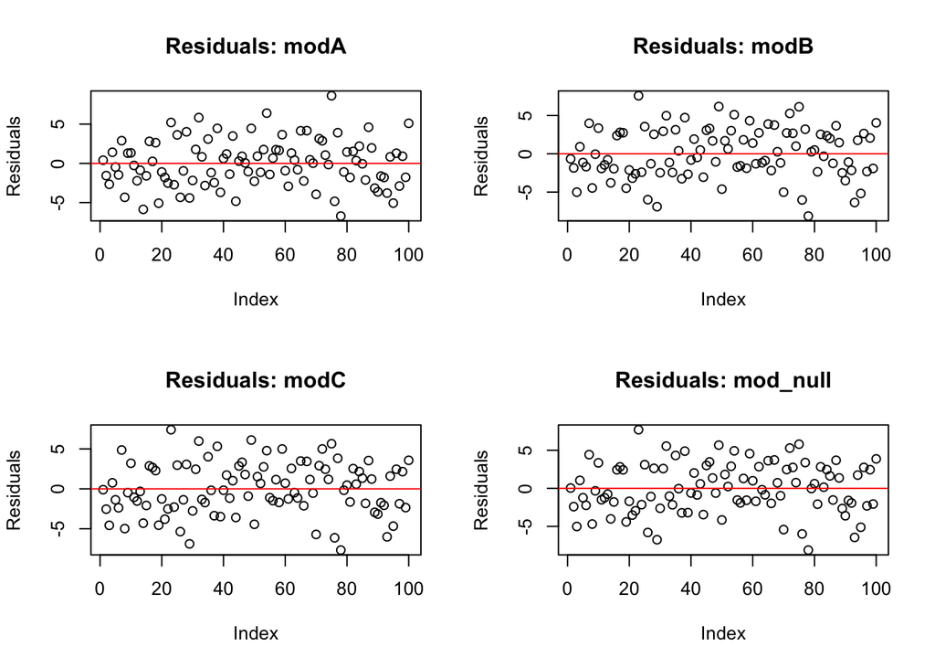

```r
# ===== Create residual plots for each model ====
# Arrange plots in a 2x2 grid.
par(mfrow = c(2,2))

plot(residuals(modA), main = 'Residuals: modA', ylab = 'Residuals', xlab = 'Index')
abline(h = 0, col = 'red')

plot(residuals(modB), main = 'Residuals: modB', ylab = 'Residuals', xlab = 'Index')
abline(h = 0, col = 'red')

plot(residuals(modC), main = 'Residuals: modC', ylab = 'Residuals', xlab = 'Index')
abline(h = 0, col = 'red')

plot(residuals(mod_null), main = 'Residuals: mod_null', ylab = 'Residuals', xlab = 'Index')
abline(h = 0, col = 'red')
```

```r
# ===== Visualize AIC values with bar chart =====

# Create a data frame for AIC values.
aic_data <- data.frame(
  Model = c('modA', 'modB', 'modC', 'mod_null'),
  AICc = c(506.9, 523.9, 526.2, 522.8)
)

print(range(aic_data$AICc))
```

```
## [1] 506.9 526.2
```

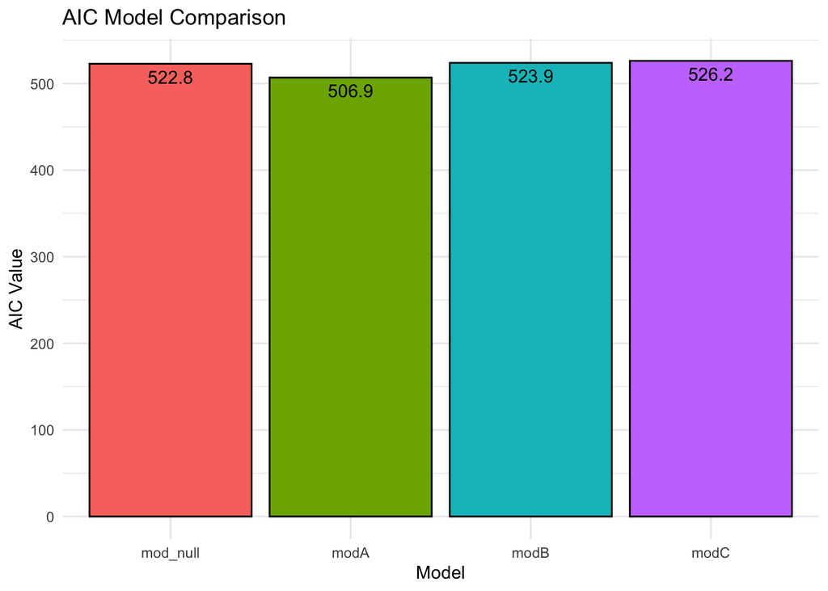

```r
# Plot AIC values.
AIC_bar_chart <- ggplot(aic_data, aes(x=Model, y=AICc, fill=Model)) +
  geom_bar(stat='identity', color='black') +
  theme_minimal() +
  labs(title='AIC Model Comparison', y = 'AIC Value') +
  theme(legend.position='none') +
  geom_text(aes(label=round(AICc, 1)), vjust=1.5)

# I could not get this line to work for the life of me!!
#  scale_y_continuous(limits=c(500, 530), breaks=seq(500, 530, 5))

AIC_bar_chart
```